## **Practical Machine Learning Project**

**Load R Package and data**

```r
library(lattice)
library(ggplot2)
library(caret)
library(randomForest)
library(rpart)
mytraining<-read.csv('training.csv')  #import training set
mytesting<-read.csv('testing.csv') #import testing set
```

```r
#set seed so that results are reproducible.
set.seed(888)
```

**Data Slicing** sample training set by k-fold cross validation

```r
mydata<-createFolds(y=mytraining$classe,k=4,list=TRUE,returnTrain=TRUE)
#Note the first fold pattern is applied below, later another three folds will be used in turns to evaluate the 'out of sample' error.
training<-mytraining[mydata$Fold1,]  #subtraining set sampled from training set
testing<-mytraining[-mydata$Fold1,]  #subtesting set sampled from training set
```

```r
#Note that the additional column 'row.names' is generated during data slicing procedure. It may be removed to avoid any further possible mistakes.
row.names(training)<-NULL
row.names(testing)<-NULL
```

**Variable Filtering** Remove variables that are relatively irrelevant to the outcome we try to predict. By that, modelling/training algorithm running time may be reduced, as well as undesired interference of non-sense variables to final predictions.

```r
#remove variables which have little variability e.g. Some variables are always true/same.
nzv<-nearZeroVar(training)
nzv
```

```
##  [1]   6  12  13  14  15  16  17  20  23  26  51  52  53  54  55  56  57
## [18]  58  59  69  70  71  72  73  74  75  78  79  81  82  87  88  89  90
## [35]  91  92  95  98 101 125 126 127 128 129 130 131 133 134 136 139 142
## [52] 143 144 145 146 147 148 149 150
```

```r
training <- training[, -nzv]
dim(training)
```

```
## [1] 14716   101
```

```r
#remove missing values: in a certain column, if over 60% of rows are 'NA's, remove the column(i.e. the variable)
nr<-0.6*nrow(training)
nc<-ncol(training)
vector=c()
for (i in 1:nc){
    if (sum(is.na(training[,i]))>nr){
        vector=c(vector,i)
    }
}
training<-training[,-vector]
```

Then remove variables by hand:

```r
# Remove 'X' variable since the order of data does not seem to matter much in this case, and it may interfere predictions if we make it a predictor.
training<-training[,-1]
```

```r
#Remove 'cvtd_timestamp', since it indicates order as well in some sense. More essentially, it is a factor variable and will inevitably lead to failure of Randomforest modelfit predictions(an error will always occur if type of predictors between training and test set are inconsistent, especially factor)
training<-training[,!(names(training)%in%c('cvtd_timestamp'))]
dim(training)
```

```
## [1] 14716    57
```

Then we do the same variable filtering to the test set sampled from the training set:

```r
nzv<-nearZeroVar(testing)
testing <- testing[, -nzv]
nr<-0.6*nrow(testing)
nc<-ncol(testing)
vector=c()
for (i in 1:nc){
    if (sum(is.na(testing[,i]))>nr){
        vector=c(vector,i)
    }
}
testing<-testing[,-vector]

testing<-testing[,-1]
testing<-testing[,!(names(testing)%in%c('cvtd_timestamp'))]
dim(testing)
```

```
## [1] 4906   57
```

**Randomforest Model fitting and test prediction**

```r
#Fit a randomforest model
modelfit <- randomForest(classe~.,data = training) #takes about only 50 seconds
# modelfit<-train(classe~.,data=training,method='rf') takes much more time to run!
modelfit
```

```
##
## Call:
##  randomForest(formula = classe ~ ., data = training)
##                Type of random forest: classification
##                      Number of trees: 500
## No. of variables tried at each split: 7
##
##         OOB estimate of  error rate: 0.11%
## Confusion matrix:
##      A    B    C    D    E  class.error
## A 4185    0    0    0    0 0.0000000000
## B    2 2845    0    0    0 0.0007024939
## C    0    3 2563    0    0 0.0011691348
## D    0    0    6 2405    1 0.0029021559
## E    0    0    0    4 2702 0.0014781966
```

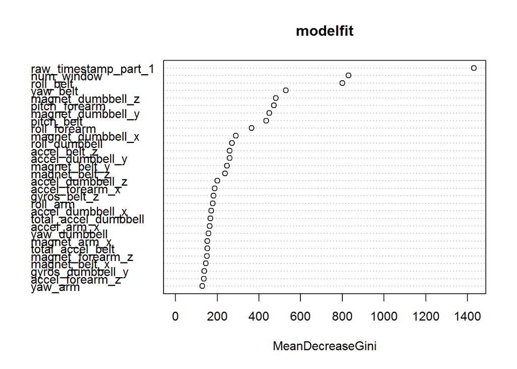

```r
varImpPlot(modelfit) #check variable importance as measured by Random Forest.
```

```r
predictions<-predict(modelfit,newdata=testing)
confusionMatrix(predictions,testing$classe) #where we can see accuracy of 0.9994, which is quite optimal.
```

```
## Confusion Matrix and Statistics
##
##           Reference
## Prediction    A    B    C    D    E
##          A 1395    0    0    0    0
##          B    0  950    1    0    0
##          C    0    0  855    1    0
##          D    0    0    0  802    0
##          E    0    0    0    1  901
##
## Overall Statistics
##
##                Accuracy : 0.9994
##                  95% CI : (0.9982, 0.9999)
##     No Information Rate : 0.2843
##     P-Value [Acc > NIR] : < 2.2e-16
##
##                   Kappa : 0.9992
##  Mcnemar's Test P-Value : NA
##
## Statistics by Class:
##
##                      Class: A Class: B Class: C Class: D Class: E
## Sensitivity            1.0000   1.0000   0.9988   0.9975   1.0000
## Specificity            1.0000   0.9997   0.9998   1.0000   0.9998
## Pos Pred Value         1.0000   0.9989   0.9988   1.0000   0.9989
## Neg Pred Value         1.0000   1.0000   0.9998   0.9995   1.0000
## Prevalence             0.2843   0.1936   0.1745   0.1639   0.1837
## Detection Rate         0.2843   0.1936   0.1743   0.1635   0.1837
## Detection Prevalence   0.2843   0.1938   0.1745   0.1635   0.1839
## Balanced Accuracy      1.0000   0.9999   0.9993   0.9988   0.9999
```

By repeating the procedure using another three folds of cross validation, accuracies are 0.9994,0.999,0.9986,0.9978 respectively. Then the expected ‘out of sample’ error calculated to be 1/4*((1-0.9994)+(1-0.999)+(1-0.9986)+(1-0.9978))=0.0013, which can be omitted.

**rpart Model fitting and test prediction**

```r
modelfitB<-rpart(classe~.,data=training) #takes about 3 seconds
#modelfitB<-train(classe~.,data=training,method='rpart') takes much more time to run!
```

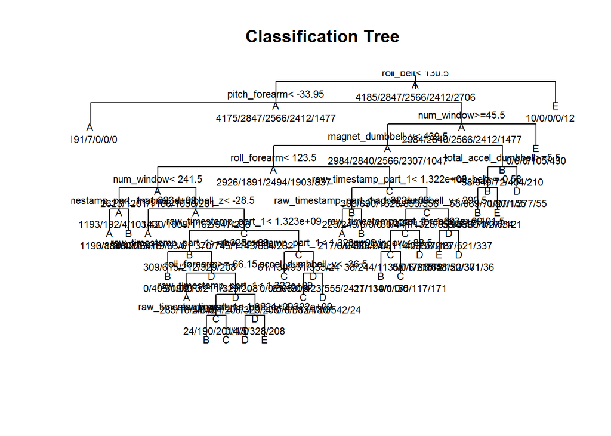

```r
plot(modelfitB,uniform=TRUE,main='Classification Tree')
text(modelfitB,use.n=TRUE,all=TRUE,cex=0.7)
```

```r
predictionsB<-predict(modelfitB,newdata=testing,type='class')
confusionMatrix(predictionsB,testing$classe) #where accuracy of 0.8174 can be seen.
```

```
## Confusion Matrix and Statistics
##
##           Reference
## Prediction    A    B    C    D    E
##          A 1309  101   11   16   19
##          B   42  674   36   50   24
##          C    4   33  725   57   70
##          D   32   73   23  570   56
##          E    8   69   61  111  732
##
## Overall Statistics
##
##                Accuracy : 0.8174
##                  95% CI : (0.8063, 0.8281)
##     No Information Rate : 0.2843
##     P-Value [Acc > NIR] : < 2.2e-16
##
##                   Kappa : 0.7687
##  Mcnemar's Test P-Value : 2.364e-16
##
## Statistics by Class:
##
##                      Class: A Class: B Class: C Class: D Class: E
## Sensitivity            0.9384   0.7095   0.8470   0.7090   0.8124
## Specificity            0.9581   0.9616   0.9595   0.9551   0.9378
## Pos Pred Value         0.8990   0.8160   0.8155   0.7560   0.7462
## Neg Pred Value         0.9751   0.9324   0.9674   0.9436   0.9569
## Prevalence             0.2843   0.1936   0.1745   0.1639   0.1837
## Detection Rate         0.2668   0.1374   0.1478   0.1162   0.1492
## Detection Prevalence   0.2968   0.1684   0.1812   0.1537   0.2000
## Balanced Accuracy      0.9482   0.8355   0.9032   0.8320   0.8751
```

By repeating the procedure using another three folds of cross validation, accuracies are 0.8174,0.8283,0.8444,0.8257 respectively. Then the expected ‘out of sample’ error calculated to be 1/4*((1-0.8174)+(1-0.8283)+(1-0.8444)+(1-0.8257))=0.17105, which is more than 100 times than that of randomforest.

**Real Prediction by randomforest**

```r
#Randomforest model will be used to predict real testing set due to optimal accuracy.
```

```r
#Do similar variable filtering to the real testing set:
nzv<-nearZeroVar(mytesting)
mytesting <- mytesting[, -nzv]
mytesting<-mytesting[,-1]
mytesting<-mytesting[,!(names(mytesting)%in%c('cvtd_timestamp'))]
dim(mytesting)
```

```
## [1] 20 57
```

```r
predictions<-predict(modelfit,newdata=mytesting) #In this case, the modelfit uses the 1st fold of the training set.
predictions
```

```
##  1  2  3  4  5  6  7  8  9 10 11 12 13 14 15 16 17 18 19 20
##  B  A  B  A  A  E  D  B  A  A  B  C  B  A  E  E  A  B  B  B
## Levels: A B C D E
```

**Submission**

```r
answers<-as.character(predictions)
pml_write_files = function(x){
  n = length(x)
  for(i in 1:n){
    filename = paste0("problem_id_",i,".txt")
    write.table(x[i],file=filename,quote=FALSE,row.names=FALSE,col.names=FALSE)
  }
}
pml_write_files(answers)
```

**Comment**

```r
# 1.Use of other 3 folds yields the same result due to fairly high accuracy of randomforest modelling.
# The results are always: BABAA-EDBAA-BCBAE-EABBB.
# 2.Instead of setting 'cv' to trControl as an argument of train function, it is much faster to do cross validation 'by hand'. The main reason would be: By experiment, the running time of train function is much greater!
# Recall:
# modelfit<-randomForest(classe~.,data = training)  takes about only 50 seconds
# modelfit<-train(classe~.,data=training,method='rf') takes much more time to run, let alone specifying trControl!
```